# DATA PROS - Project 2

DATA PROS

NOV-2019

# Brief EDA on the dataset:

# Inspect dataset: Data Dictionary

```
##  [1] "X"        "outcome"  "sex"      "age"      "yronset"  "premi"
##  [7] "smstat"   "diabetes" "highbp"   "hichol"   "angina"   "stroke"
## [13] "hosp"
```

```
## 'data.frame':    6367 obs. of  13 variables:
##  $ X       : int  1 2 3 4 5 6 7 8 9 10 ...
##  $ outcome : chr  "live" "live" "live" "live" ...
##  $ sex     : chr  "f" "m" "m" "m" ...
##  $ age     : int  63 59 68 46 48 55 56 68 69 64 ...
##  $ yronset : int  85 85 85 85 85 85 85 85 85 85 ...
##  $ premi   : chr  "n" "y" "n" "n" ...
##  $ smstat  : chr  "x" "x" "n" "c" ...
##  $ diabetes: chr  "n" "n" "n" "n" ...
##  $ highbp  : chr  "y" "y" "y" "n" ...
##  $ hichol  : chr  "y" "n" "n" "n" ...
##  $ angina  : chr  "n" "n" "n" "n" ...
##  $ stroke  : chr  "n" "n" "n" "n" ...
##  $ hosp    : chr  "y" "y" "y" "y" ...
```

Dataframe with 13 variables (including X, counter of number of samples) and 6367 samples.

**Inspect the 10 columns with data type characters**

```
## [1] "outcome"
```

```
##
## dead live
## 2842 3525
```

```
## [1] "sex"
```

```
##
##    f    m
## 1762 4605
```

```
## [1] "premi"
```

```
##
##    n   nk    y
## 4122  734 1511
```

```
## [1] "smstat"
```

```
##
##    c    n   nk    x
## 2051 1460  918 1938
```

```
## [1] "diabetes"
```

```
##
##    n   nk    y
## 4664  885  818
```

```
## [1] "highbp"
```

```
##
##    n   nk    y
## 2542  948 2877
```

```
## [1] "hicol"
```

```
##
##    n   nk    y
## 3294 1233 1840
```

```
## [1] "angina"
```

```
##
##    n   nk    y
## 3473  975 1919
```

```
## [1] "stroke"
```

```
##
##    n   nk    y
## 4881  926  560
```

```
## [1] "hosp"
```

```
##
##    n    y
## 1925 4442
```

Large number of Not Known (“nk”) values in 7 columns: “premi”,“smstat”,“diabetes”,“highbp”,“hichol”,“angina” and “stroke”

3 Columns with complete info: “outcome”, “sex” and “hosp”

**Inspect the 2 columns with data type numeric**

```
##    Min. 1st Qu.  Median    Mean 3rd Qu.    Max.
##    35.0    55.0    61.0    59.4    66.0    69.0
```

```
##    Min. 1st Qu.  Median    Mean 3rd Qu.    Max.
##    85.0    87.0    89.0    88.7    91.0    93.0
```

The variables with complete information are: Sex, Age, Outcome, Hospitalization, and Year of Onset.

## Following findings of univariate analysis, use Logistic Regression to:

1- Determine if any of the predictors confound the association between the other predictors and the outcome, stratified by sex.

2- Determine the variables that best predict the odds of mortality among our sample population, stratified by sex

Approach is forward selection: add variables one-at-a-time until we cannot find any variables that improve the model.

The fit of the model is evaluated as measured by McFadden: the result is a pseudo R2 to undertand the percentage of variation explained by the model.

## FEMALES

Univariate results:

| Variable | McFadden |
| --- | --- |
| Hospitalization | 0.395 |
| Age | 0.006 |
| High cholesterol | 0.272 |
| Year onset | 0.005 |
| Stroke | 0.199 |
| Angina | 0.214 |
| Previous myocardial infarction | 0.151 |
| Diabetes | 0.193 |

Highest McFadden (0.541) corresponds to hosp+hichol.

I add hichol to the model since it improves it from roughly 40% to 54%

McFadden of full model is 0.585

I add yronset to the model since it improves the model: from roughly 54% to 56.2%

McFadden of full model is 0.585

Highest McFadden (0.564) corresponds to hosp+hichol+yronset+angina

I add angina to the model since it improves the model: from roughly 56.2% to 56.4%

McFadden of full model is 0.585

Highest McFadden (0.572) corresponds to hosp+hichol+yronset+angina+stroke

I add stroke to the model since it improves the model: from roughly 56.4% to 57.2%

McFadden of full model is 0.585

Highest McFadden(0.578) corresponds to hosp+hichol+yronset+angina+stroke+age and hosp+hichol+yronset+angina+stroke+premi

AIC is pratically the same. Thus, I choose to add the variable with the smallest p-value: age.

I add age to the model since it improves it from roughly 57.2% to 57.8%

```r
#perform logistic regression variables hosp + hichol + yronset + angina + stroke + age + premi
glmf34<-glm(outcome ~ hosp+hichol+yronset+angina+stroke+age+premi, data = monica.na.bin.f, family = "binomial")
#perform logistic regression variables hosp + hichol + yronset + angina + stroke + age + diabetes
glmf35<-glm(outcome ~ hosp+hichol+yronset+angina+stroke+age+diabetes, data = monica.na.bin.f, family = "binomial")

#run McFadden
glmf34pr2 = pR2(glmf34)
glmf34pr2
```

```
##       llh   llhNull        G2  McFadden      r2ML      r2CU
##  -504.498 -1211.277  1413.558     0.583     0.655     0.781
```

```r
glmf35pr2 = pR2(glmf35)
glmf35pr2
```

```
##       llh   llhNull        G2  McFadden      r2ML      r2CU
##  -508.536 -1211.277  1405.482     0.580     0.649     0.777
```

McFadden of full model is 0.585

Highest McFadden(0.583) corresponds to hosp+hichol+yronset+angina+stroke+age+premi

I add premi to the model since it improves it from roughly 57.8% to 58.3%

Last variable to add is diabetes since full model has the highest McFadden.

## MALES

McFadden value of full model: 0.66

Univariate results:

| Variable | McFadden |
| --- | --- |
| Hospitalization | 0.511 |
| Age | 0.024 |
| High cholesterol | 0.225 |
| Year onset | 0.003 |
| Stroke | 0.192 |
| Angina | 0.194 |
| Previous myocardial infarction | 0.145 |
| Diabetes | 0.178 |

Highest McGFadden(0.615) corresponds to hosp+hichol.

I add hichol to the model since it improves the model: from roughly 51% to 61.5%

Highest McFadden (0.633) corresponds to hosp+hichol+angina, I add angina to the model since it improves the model: from roughly 61.5% to 63.3%

Highest McFadden (0.650) corresponds to hosp+hichol+angina+agecat+premi, I add age to the model since it improves the model: from roughly 64.2% to 65.0%

Highest McFadden (0.657) corresponds to hosp+hichol+angina+agecat+premi+stroke, I add stroke to the model since it improves the model: from roughly 65.0% to 65.7%

Highest McFadden (0.661) corresponds to hosp+hichol+angina+agecat+premi+stroke+yronset, I add yronset to the model since it improves the model: from roughly 65.7% to 66.1%

# KNN:

At random, we have an 34.8% chance of classifying correctly outcome=dead.

```
## dead
## 34.8
```

Before using the classifier, we can see that, at random, we have 34.8% chance of classifying “outcome = dead” correctly.

Let’s split the data into training and test sets. We divided 70% of the data into the training set and the remaining 30% into the test set.

## Classifier with 3-nearest neighbors

```
##
##
##    Cell Contents
## |-------------------------|
## |                       N |
## |           N / Row Total |
## |           N / Col Total |
## |         N / Table Total |
## |-------------------------|
##
##
## Total Observations in Table:  1467
##
##
##                   | predict3NN
## monica.testLabels |      dead |      live | Row Total |
## ------------------|-----------|-----------|-----------|
##              dead |       313 |       172 |       485 |
##                   |     0.645 |     0.355 |     0.331 |
##                   |     0.910 |     0.153 |           |
##                   |     0.213 |     0.117 |           |
## ------------------|-----------|-----------|-----------|
##              live |        31 |       951 |       982 |
##                   |     0.032 |     0.968 |     0.669 |
##                   |     0.090 |     0.847 |           |
##                   |     0.021 |     0.648 |           |
## ------------------|-----------|-----------|-----------|
##      Column Total |       344 |      1123 |      1467 |
##                   |     0.234 |     0.766 |           |
## ------------------|-----------|-----------|-----------|
##
##
```

## Classifier 5-nearest neighbors

```
##
##
##    Cell Contents
## |-------------------------|
## |                       N |
## |           N / Row Total |
## |           N / Col Total |
## |         N / Table Total |
## |-------------------------|
##
##
## Total Observations in Table:  1467
##
##
##                   | predict5NN
## monica.testLabels |      dead |      live | Row Total |
## ------------------|-----------|-----------|-----------|
##              dead |       307 |       178 |       485 |
##                   |     0.633 |     0.367 |     0.331 |
##                   |     0.942 |     0.156 |           |
##                   |     0.209 |     0.121 |           |
## ------------------|-----------|-----------|-----------|
##              live |        19 |       963 |       982 |
##                   |     0.019 |     0.981 |     0.669 |
##                   |     0.058 |     0.844 |           |
##                   |     0.013 |     0.656 |           |
## ------------------|-----------|-----------|-----------|
##      Column Total |       326 |      1141 |      1467 |
##                   |     0.222 |     0.778 |           |
## ------------------|-----------|-----------|-----------|
##
##
```

## Classifier with 7-nearest neighbors

```
##
##
##    Cell Contents
## |-------------------------|
## |                       N |
## |           N / Row Total |
## |           N / Col Total |
## |         N / Table Total |
## |-------------------------|
##
##
## Total Observations in Table:  1467
##
##
##                   | predict7NN
## monica.testLabels |      dead |      live | Row Total |
## ------------------|-----------|-----------|-----------|
##              dead |       305 |       180 |       485 |
##                   |     0.629 |     0.371 |     0.331 |
##                   |     0.968 |     0.156 |           |
##                   |     0.208 |     0.123 |           |
## ------------------|-----------|-----------|-----------|
##              live |        10 |       972 |       982 |
##                   |     0.010 |     0.990 |     0.669 |
##                   |     0.032 |     0.844 |           |
##                   |     0.007 |     0.663 |           |
## ------------------|-----------|-----------|-----------|
##      Column Total |       315 |      1152 |      1467 |
##                   |     0.215 |     0.785 |           |
## ------------------|-----------|-----------|-----------|
##
##
```

## Predict optimal number of K

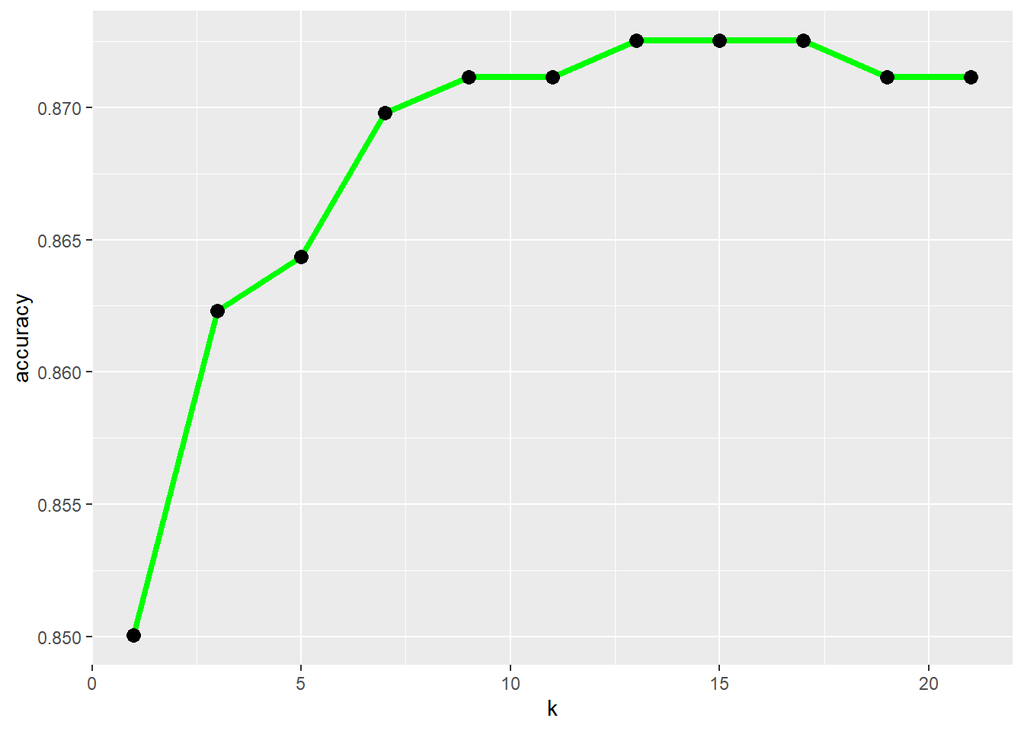

# 2. Classify outcome based on age and risk predictors for female population

At random, we have an 34.1% chance of correctly picking outcome=dead for female population

```
## dead
## 34.1
```

## Predict optimal number of K

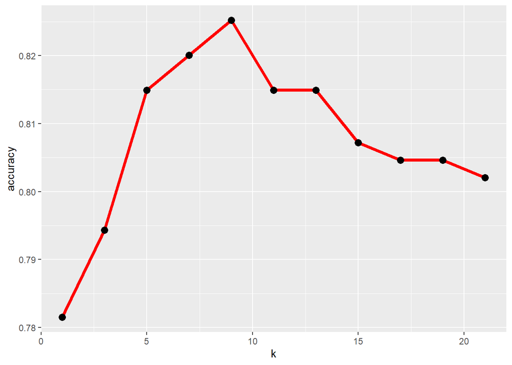

## Classifier with 3-nearest neighbors

```
##
##
##    Cell Contents
## |-------------------------|
## |                       N |
## |           N / Row Total |
## |           N / Col Total |
## |         N / Table Total |
## |-------------------------|
##
##
## Total Observations in Table:  389
##
##
##                  | predict3NN.women
## women.testLabels |      dead |      live | Row Total |
## -----------------|-----------|-----------|-----------|
##             dead |        63 |        64 |       127 |
##                  |     0.496 |     0.504 |     0.326 |
##                  |     0.759 |     0.209 |           |
##                  |     0.162 |     0.165 |           |
## -----------------|-----------|-----------|-----------|
##             live |        20 |       242 |       262 |
##                  |     0.076 |     0.924 |     0.674 |
##                  |     0.241 |     0.791 |           |
##                  |     0.051 |     0.622 |           |
## -----------------|-----------|-----------|-----------|
##     Column Total |        83 |       306 |       389 |
##                  |     0.213 |     0.787 |           |
## -----------------|-----------|-----------|-----------|
##
##
```

## Subset significant risk factors for women

We ran the classifier only with those predictors that were significant for women (according to the results of the logistic regression from the first part of the project), to assess the impact in the predictive accuracy of the model. The predictors are: diabetes, high cholesterol, stroke, hospitalization, year of onset, and age of diagnosis.

```
##
##
##    Cell Contents
## |-------------------------|
## |                       N |
## |           N / Row Total |
## |           N / Col Total |
## |         N / Table Total |
## |-------------------------|
##
##
## Total Observations in Table:  389
##
##
##                  | predict3NN.w.sub
## w.sub.testLabels |      dead |      live | Row Total |
## -----------------|-----------|-----------|-----------|
##             dead |        24 |       103 |       127 |
##                  |     0.189 |     0.811 |     0.326 |
##                  |     0.308 |     0.331 |           |
##                  |     0.062 |     0.265 |           |
## -----------------|-----------|-----------|-----------|
##             live |        54 |       208 |       262 |
##                  |     0.206 |     0.794 |     0.674 |
##                  |     0.692 |     0.669 |           |
##                  |     0.139 |     0.535 |           |
## -----------------|-----------|-----------|-----------|
##     Column Total |        78 |       311 |       389 |
##                  |     0.201 |     0.799 |           |
## -----------------|-----------|-----------|-----------|
##
##
```

The model is not a good fit, especially for outcome=dead:

# 3. Classify outcome based on age and risk predictors for male population

At random, we have an 35% chance of correctly picking outcome=dead for male population.

```
## dead
##   35
```

## Predict optimal number of K

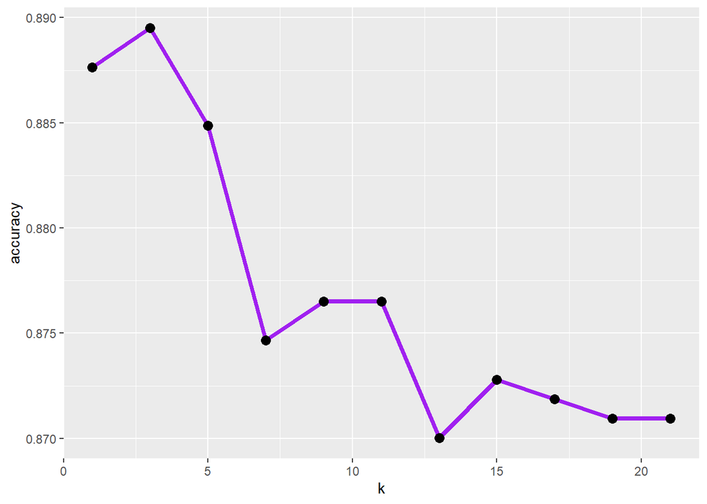

## Classifier with 13-nearest neighbors

```
##
##
##    Cell Contents
## |-------------------------|
## |                       N |
## |           N / Row Total |
## |           N / Col Total |
## |         N / Table Total |
## |-------------------------|
##
##
## Total Observations in Table:  1077
##
##
##                | predict13NN.men
## men.testLabels |      dead |      live | Row Total |
## ---------------|-----------|-----------|-----------|
##           dead |       244 |       135 |       379 |
##                |     0.644 |     0.356 |     0.352 |
##                |     0.996 |     0.162 |           |
##                |     0.227 |     0.125 |           |
## ---------------|-----------|-----------|-----------|
##           live |         1 |       697 |       698 |
##                |     0.001 |     0.999 |     0.648 |
##                |     0.004 |     0.838 |           |
##                |     0.001 |     0.647 |           |
## ---------------|-----------|-----------|-----------|
##   Column Total |       245 |       832 |      1077 |
##                |     0.227 |     0.773 |           |
## ---------------|-----------|-----------|-----------|
##
##
```

## Subset significant risk factors for men

We ran the classifier only with those predictors that were significant for men (according to the results of the logistic regression from the first part of the project), to assess the impact in the predictive accuracy of the model. The predictors are: previous myocardial infarction, smoking status, angina, hospitalization, year of onset, and age of diagnosis.

```
##
##
##    Cell Contents
## |-------------------------|
## |                       N |
## |           N / Row Total |
## |           N / Col Total |
## |         N / Table Total |
## |-------------------------|
##
##
## Total Observations in Table:  1077
##
##
##                  | predict13NN.m.sub
## m.sub.testLabels |      dead |      live | Row Total |
## -----------------|-----------|-----------|-----------|
##             dead |        32 |       347 |       379 |
##                  |     0.084 |     0.916 |     0.352 |
##                  |     0.381 |     0.349 |           |
##                  |     0.030 |     0.322 |           |
## -----------------|-----------|-----------|-----------|
##             live |        52 |       646 |       698 |
##                  |     0.074 |     0.926 |     0.648 |
##                  |     0.619 |     0.651 |           |
##                  |     0.048 |     0.600 |           |
## -----------------|-----------|-----------|-----------|
##     Column Total |        84 |       993 |      1077 |
##                  |     0.078 |     0.922 |           |
## -----------------|-----------|-----------|-----------|
##
##
```

The model is not a good fit, especially for outcome=dead:

# Summary for KNN:

## Classify outcome based on age, sex, and risk predictors

[output not shown]

## Classify outcome based on age and risk predictors stratified by sex

| Sex | k | Accuracy=All Risk Factors | Accuracy=subset of risk factors |
| --- | --- | --- | --- |
| Female | 3 | 78.41% | 59.64% |
| Male | 13 | 87.37% | 62.95% |

### DECISION TREES:

**FEATURE SELECTION**

## Importing needed packages:

## FEATURE SELECTION FOR SUBSET OF FEMALES:

```
## Reordering variables and trying again:
```

```
## Subset selection object
## Call: regsubsets.formula(outcome ~ ., data = monica.f, nvmax = 14)
## 20 Variables  (and intercept)
##            Forced in Forced out
## X              FALSE      FALSE
## age            FALSE      FALSE
## yronset        FALSE      FALSE
## premink        FALSE      FALSE
## premiy         FALSE      FALSE
## smstatn        FALSE      FALSE
## smstatnk       FALSE      FALSE
## smstatx        FALSE      FALSE
## diabetesnk     FALSE      FALSE
## diabetesy      FALSE      FALSE
## highbpnk       FALSE      FALSE
## highbpy        FALSE      FALSE
## hicholnk       FALSE      FALSE
## hicholy        FALSE      FALSE
## anginank       FALSE      FALSE
## anginay        FALSE      FALSE
## strokenk       FALSE      FALSE
## strokey        FALSE      FALSE
## hospy          FALSE      FALSE
## sexm           FALSE      FALSE
## 1 subsets of each size up to 15
## Selection Algorithm: exhaustive
##           X   sexm age yronset premink premiy smstatn smstatnk smstatx
## 1  ( 1 )  " " " "  " " " "     " "     " "    " "     " "      " "
## 2  ( 1 )  " " " "  " " " "     " "     " "    " "     " "      " "
## 3  ( 1 )  " " " "  "*" " "     " "     " "    " "     " "      " "
## 4  ( 1 )  " " " "  "*" " "     " "     " "    " "     " "      " "
## 5  ( 1 )  " " " "  "*" " "     " "     " "    " "     " "      " "
## 6  ( 1 )  " " " "  "*" " "     " "     " "    " "     " "      " "
## 7  ( 1 )  "*" " "  "*" " "     " "     " "    " "     " "      " "
## 8  ( 1 )  "*" " "  "*" " "     " "     " "    " "     "*"      " "
## 9  ( 1 )  "*" " "  "*" " "     " "     "*"    " "     "*"      " "
## 10  ( 1 ) "*" " "  "*" " "     " "     "*"    "*"     "*"      " "
## 11  ( 1 ) "*" " "  "*" " "     " "     "*"    " "     "*"      " "
## 12  ( 1 ) "*" " "  "*" " "     " "     "*"    "*"     "*"      " "
## 13  ( 1 ) "*" " "  "*" " "     " "     "*"    "*"     "*"      " "
```

[output cut: 19 more lines]

```
## 1  ( 1 )  " "     " "      " "     "*"
## 2  ( 1 )  " "     " "      " "     "*"
## 3  ( 1 )  " "     " "      " "     "*"
## 4  ( 1 )  " "     " "      " "     "*"
## 5  ( 1 )  " "     " "      "*"     "*"
## 6  ( 1 )  "*"     " "      "*"     "*"
## 7  ( 1 )  " "     " "      "*"     "*"
## 8  ( 1 )  " "     " "      "*"     "*"
## 9  ( 1 )  " "     " "      "*"     "*"
## 10  ( 1 ) " "     " "      "*"     "*"
## 11  ( 1 ) " "     "*"      "*"     "*"
## 12  ( 1 ) " "     "*"      "*"     "*"
## 13  ( 1 ) "*"     "*"      "*"     "*"
## 14  ( 1 ) "*"     "*"      "*"     "*"
## 15  ( 1 ) "*"     "*"      "*"     "*"
```

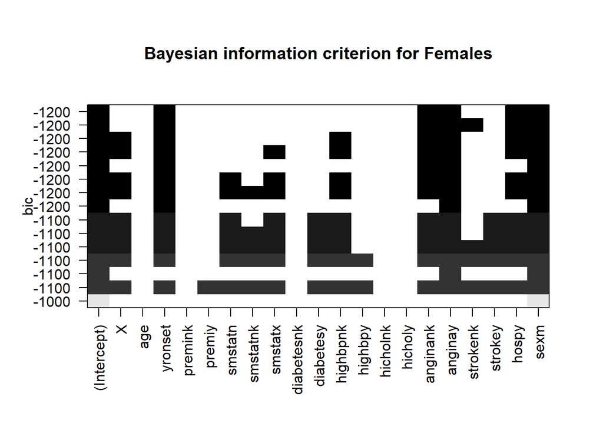

```r
plot(regfit.full,scale="bic",main="Bayesian information criterion for Females")
```

For females according to BIC yronset, angina and hosp are the most significant.

## FEATURE SELECTION FOR SUBSET OF MALES:

```
## Reordering variables and trying again:
```

```
## Subset selection object
## Call: regsubsets.formula(outcome ~ ., data = monica.m, nvmax = 14)
## 20 Variables  (and intercept)
##            Forced in Forced out
## X              FALSE      FALSE
## age            FALSE      FALSE
## yronset        FALSE      FALSE
## premink        FALSE      FALSE
## premiy         FALSE      FALSE
## smstatn        FALSE      FALSE
## smstatnk       FALSE      FALSE
## smstatx        FALSE      FALSE
## diabetesnk     FALSE      FALSE
## diabetesy      FALSE      FALSE
## highbpnk       FALSE      FALSE
## highbpy        FALSE      FALSE
## hicholnk       FALSE      FALSE
## hicholy        FALSE      FALSE
## anginank       FALSE      FALSE
## anginay        FALSE      FALSE
## strokenk       FALSE      FALSE
## strokey        FALSE      FALSE
## hospy          FALSE      FALSE
## sexm           FALSE      FALSE
## 1 subsets of each size up to 15
## Selection Algorithm: exhaustive
##           X   sexm age yronset premink premiy smstatn smstatnk smstatx
## 1  ( 1 )  " " " "  " " " "     " "     " "    " "     " "      " "
## 2  ( 1 )  " " " "  " " " "     " "     " "    " "     " "      " "
## 3  ( 1 )  " " " "  "*" " "     " "     " "    " "     " "      " "
## 4  ( 1 )  " " " "  "*" " "     " "     " "    " "     " "      " "
## 5  ( 1 )  " " " "  "*" " "     " "     " "    " "     " "      " "
## 6  ( 1 )  " " " "  "*" "*"     " "     " "    " "     " "      " "
## 7  ( 1 )  " " " "  "*" "*"     " "     " "    " "     " "      " "
## 8  ( 1 )  "*" " "  "*" "*"     " "     " "    " "     " "      " "
## 9  ( 1 )  "*" " "  "*" "*"     " "     "*"    " "     " "      " "
## 10  ( 1 ) "*" " "  "*" "*"     " "     "*"    " "     " "      " "
## 11  ( 1 ) "*" " "  "*" "*"     " "     "*"    "*"     " "      " "
## 12  ( 1 ) "*" " "  "*" "*"     " "     "*"    " "     "*"      "*"
## 13  ( 1 ) "*" " "  "*" "*"     " "     "*"    "*"     " "      " "
```

[output cut: 19 more lines]

```
## 1  ( 1 )  " "     " "      " "     "*"
## 2  ( 1 )  " "     " "      " "     "*"
## 3  ( 1 )  " "     " "      " "     "*"
## 4  ( 1 )  "*"     " "      " "     "*"
## 5  ( 1 )  "*"     " "      "*"     "*"
## 6  ( 1 )  "*"     " "      "*"     "*"
## 7  ( 1 )  "*"     " "      "*"     "*"
## 8  ( 1 )  "*"     " "      "*"     "*"
## 9  ( 1 )  "*"     " "      "*"     "*"
## 10  ( 1 ) "*"     " "      "*"     "*"
## 11  ( 1 ) "*"     " "      "*"     "*"
## 12  ( 1 ) "*"     " "      "*"     "*"
## 13  ( 1 ) "*"     "*"      "*"     "*"
## 14  ( 1 ) "*"     "*"      "*"     "*"
## 15  ( 1 ) "*"     "*"      "*"     "*"
```

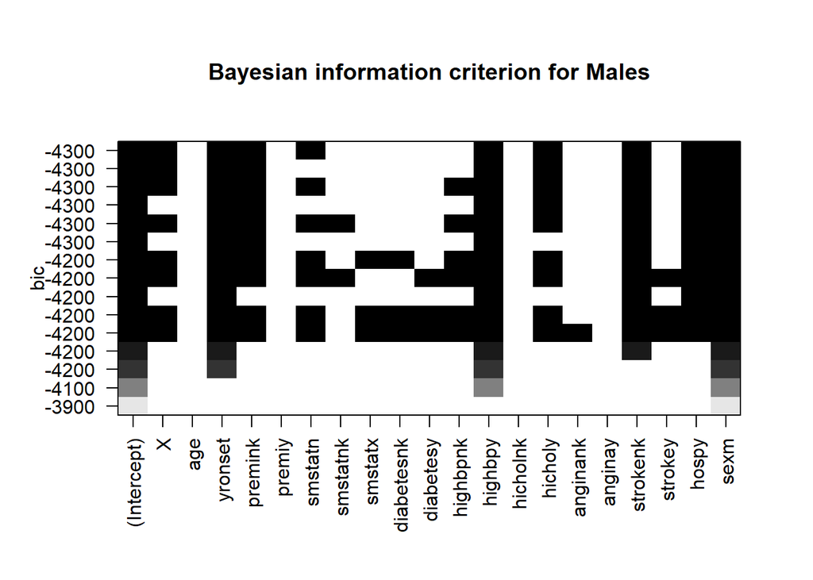

```r
plot(regfit.full,scale="bic",main="Bayesian information criterion for Males")
```

For males according to BIC yronset, premi, smstat, highbp, hichol, stroke and hosp are the most significant.

**DECISION TREES**

#### Decision trees for females subsetting by: yronset,hosp,angina.

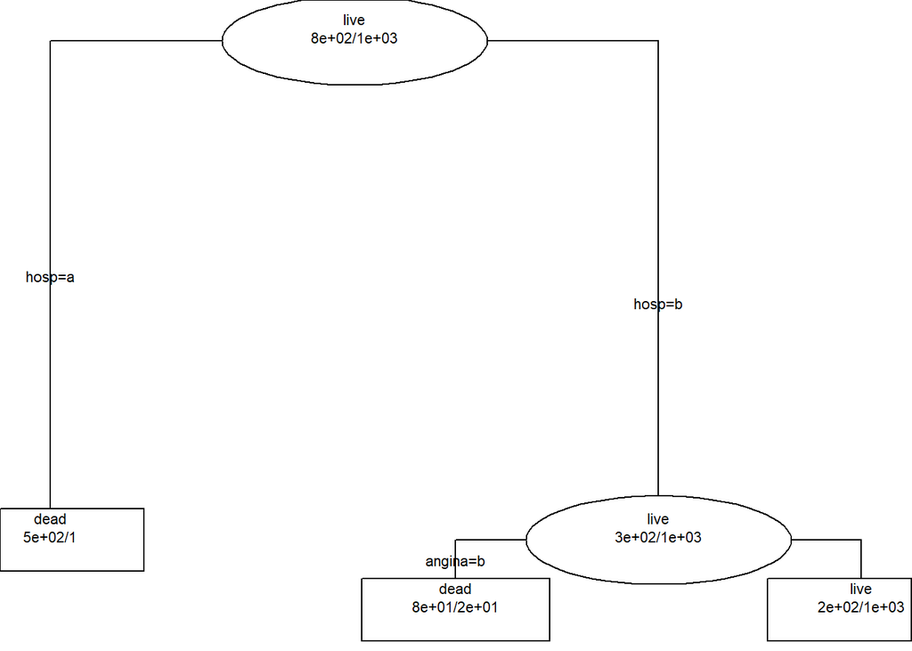

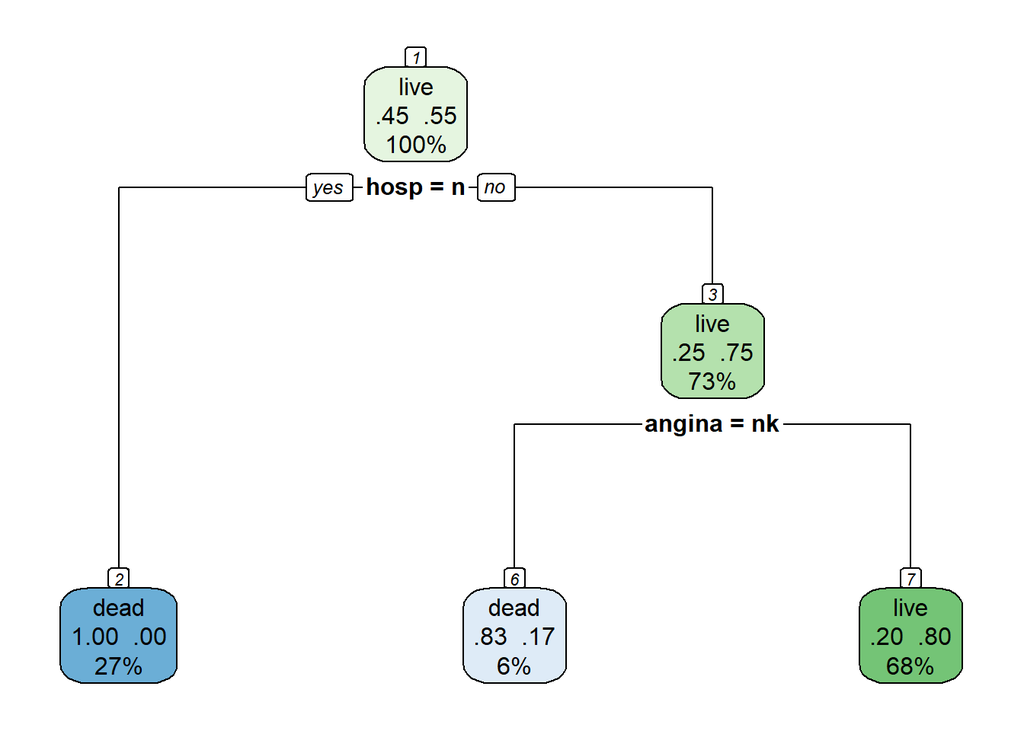

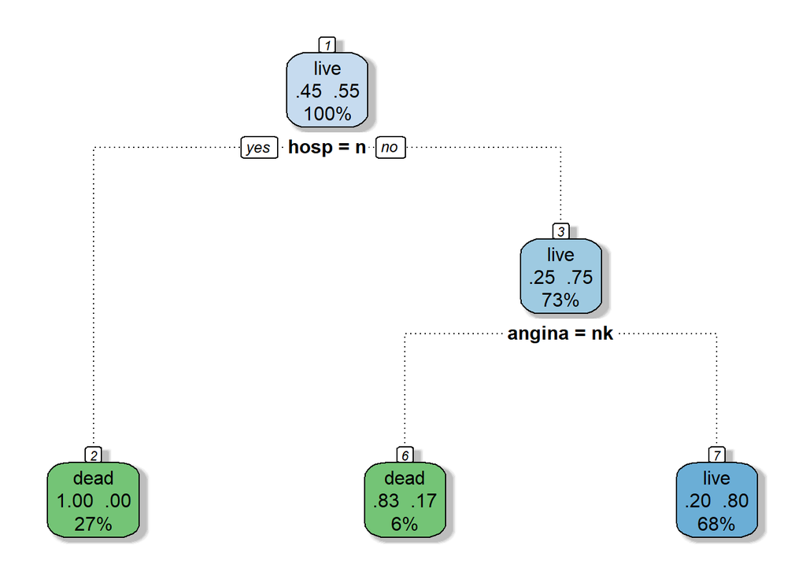

#### Decision tree for females using all the features.

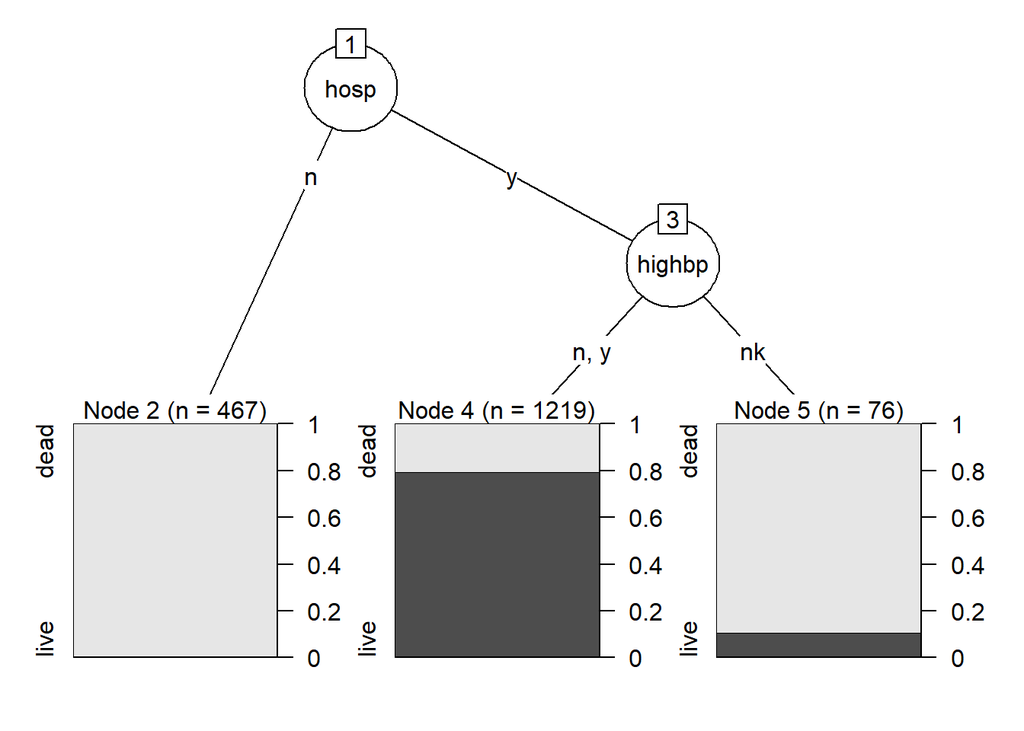

```r
fulltreeff <- C5.0(outcome~., data=monica.f)
plot(fulltreeff)
```

## Accuracy measure:

### for subset of features:

```r
loadPkg("caret")
cm1 = confusionMatrix( predict(modelf, type = "class"), reference = monica.f[, "outcome"] )
cm1
```

```
## Confusion Matrix and Statistics
##
##           Reference
## Prediction dead live
##       dead  548   18
##       live  239  957
##
##                Accuracy : 0.854
##                  95% CI : (0.837, 0.87)
##     No Information Rate : 0.553
##     P-Value [Acc > NIR] : <2e-16
##
##                   Kappa : 0.697
##
##  Mcnemar's Test P-Value : <2e-16
##
##             Sensitivity : 0.696
##             Specificity : 0.982
##          Pos Pred Value : 0.968
##          Neg Pred Value : 0.800
##              Prevalence : 0.447
##          Detection Rate : 0.311
##    Detection Prevalence : 0.321
##       Balanced Accuracy : 0.839
##
##        'Positive' Class : dead
##
```

### for the entire dataset:

```r
loadPkg("caret")
cmf = confusionMatrix( predict(fullmodelf, type = "class"), reference = monica.f[, "outcome"] )
cmf
```

```
## Confusion Matrix and Statistics
##
##           Reference
## Prediction dead live
##       dead  548   18
##       live  239  957
##
##                Accuracy : 0.854
##                  95% CI : (0.837, 0.87)
##     No Information Rate : 0.553
##     P-Value [Acc > NIR] : <2e-16
##
##                   Kappa : 0.697
##
##  Mcnemar's Test P-Value : <2e-16
##
##             Sensitivity : 0.696
##             Specificity : 0.982
##          Pos Pred Value : 0.968
##          Neg Pred Value : 0.800
##              Prevalence : 0.447
##          Detection Rate : 0.311
##    Detection Prevalence : 0.321
##       Balanced Accuracy : 0.839
##
##        'Positive' Class : dead
##
```

#### Decision trees for males subsetting by: yronset,premi,smstat,highbp,hichol,stroke,hosp.

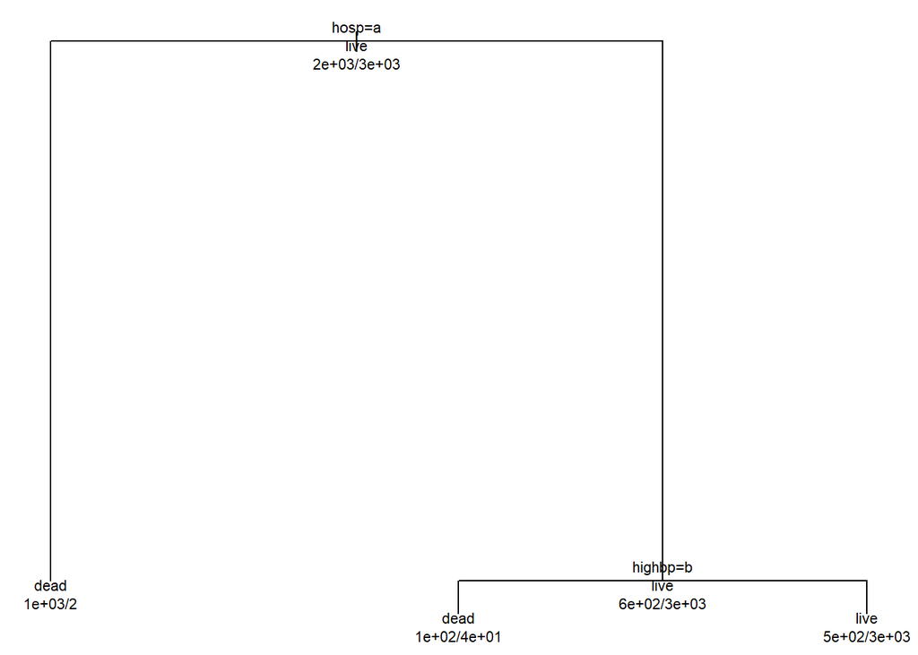

```r
# tree model for males
modelm <- rpart(outcome~yronset+premi+smstat+highbp+hichol+stroke+hosp, data=monica.m)
par(xpd = NA, mar = rep(0.7, 4))
plot(modelm, compress = TRUE)
text(modelm, cex = 0.7, use.n = TRUE, fancy = FALSE, all = TRUE)
```

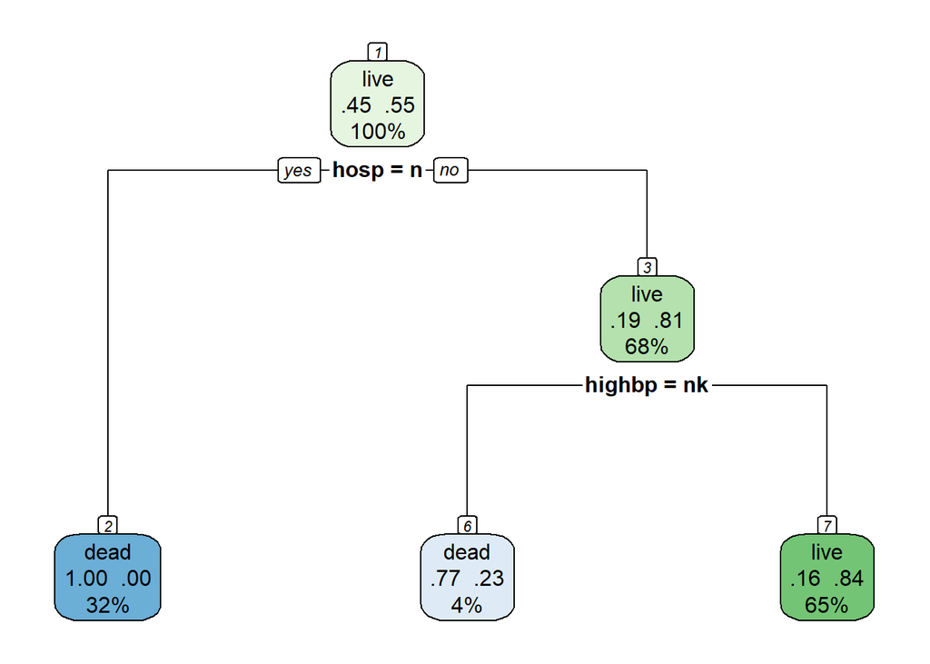

```r
rpart.plot(modelm, extra = 104, nn = TRUE)
```

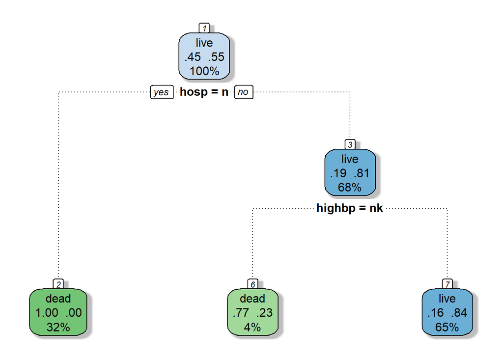

```r
fancyRpartPlot(modelm)
```

#### Decision tree for males using all the features.

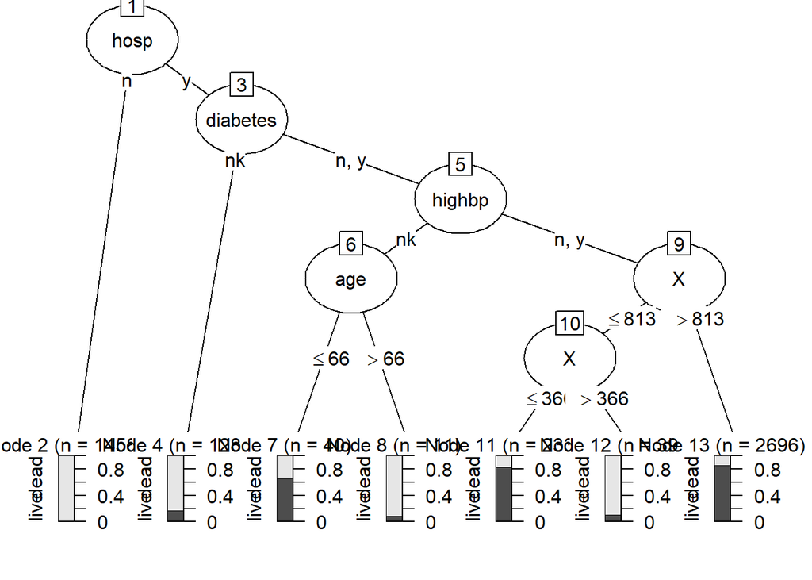

```r
fulltreemm <- C5.0(outcome~., data=monica.m)
plot(fulltreemm)
```

## Accuracy measure:

### for subset of features:

```r
loadPkg("caret")
cm = confusionMatrix( predict(modelm, type = "class"), reference = monica.m[, "outcome"] )
cm
```

```
## Confusion Matrix and Statistics
##
##           Reference
## Prediction dead live
##       dead 1584   41
##       live  471 2509
##
##                Accuracy : 0.889
##                  95% CI : (0.879, 0.898)
##     No Information Rate : 0.554
##     P-Value [Acc > NIR] : <2e-16
##
##                   Kappa : 0.77
##
##  Mcnemar's Test P-Value : <2e-16
##
##             Sensitivity : 0.771
##             Specificity : 0.984
##          Pos Pred Value : 0.975
##          Neg Pred Value : 0.842
##              Prevalence : 0.446
##          Detection Rate : 0.344
##    Detection Prevalence : 0.353
##       Balanced Accuracy : 0.877
##
##        'Positive' Class : dead
##
```

### for the entire dataset:

```r
loadPkg("caret")
cmm = confusionMatrix( predict(fullmodelm, type = "class"), reference = monica.m[, "outcome"] )
cmm
```

```
## Confusion Matrix and Statistics
##
##           Reference
## Prediction dead live
##       dead 1584   41
##       live  471 2509
##
##                Accuracy : 0.889
##                  95% CI : (0.879, 0.898)
##     No Information Rate : 0.554
##     P-Value [Acc > NIR] : <2e-16
##
##                   Kappa : 0.77
##
##  Mcnemar's Test P-Value : <2e-16
##
##             Sensitivity : 0.771
##             Specificity : 0.984
##          Pos Pred Value : 0.975
##          Neg Pred Value : 0.842
##              Prevalence : 0.446
##          Detection Rate : 0.344
##    Detection Prevalence : 0.353
##       Balanced Accuracy : 0.877
##
##        'Positive' Class : dead
##
```

## Splitting the data into training and testing data stratified by sex(females):

```r
set.seed(1234)
train_index <- sample(seq_len(nrow(monica.f)), size = 0.8*nrow(monica.f))
monica.f_train<-monica.f[train_index, ]
monica.f_test<-monica.f[-train_index, ]
```

```r
set.seed(1234)
train_index <- sample(seq_len(nrow(monica.m)), size = 0.8*nrow(monica.m))
monica.m_train<-monica.m[train_index, ]
monica.m_test<-monica.m[-train_index, ]
```

## Prediction and accuracy measure:

**accuracy measure for tree for full dataset statified by sex(female)**

```r
monica.f_pred<-predict(fulltreeff, monica.f_test[ ,-c(2)])  #elimnating outcome variable which would be our predictor
confusionMatrix(table(monica.f_pred, monica.f_test$outcome))
```

```
## Confusion Matrix and Statistics
##
##
## monica.f_pred dead live
##          dead  104    2
##          live   51  196
##
##                Accuracy : 0.85
##                  95% CI : (0.808, 0.885)
##     No Information Rate : 0.561
##     P-Value [Acc > NIR] : < 2e-16
##
##                   Kappa : 0.684
##
##  Mcnemar's Test P-Value : 4.3e-11
##
##             Sensitivity : 0.671
##             Specificity : 0.990
##          Pos Pred Value : 0.981
##          Neg Pred Value : 0.794
##              Prevalence : 0.439
##          Detection Rate : 0.295
##    Detection Prevalence : 0.300
##       Balanced Accuracy : 0.830
##
##        'Positive' Class : dead
##
```

**accuracy measure for tree for full dataset statified by sex(male)**

```r
monica.m_pred<-predict(fulltreemm, monica.m_test[ ,-c(2)])  #elimnating outcome variable which would be our predictor
confusionMatrix(table(monica.m_pred, monica.m_test$outcome))
```

```
## Confusion Matrix and Statistics
##
##
## monica.m_pred dead live
##          dead  324    4
##          live   99  494
##
##                Accuracy : 0.888
##                  95% CI : (0.866, 0.908)
##     No Information Rate : 0.541
##     P-Value [Acc > NIR] : <2e-16
##
##                   Kappa : 0.771
##
##  Mcnemar's Test P-Value : <2e-16
##
##             Sensitivity : 0.766
##             Specificity : 0.992
##          Pos Pred Value : 0.988
##          Neg Pred Value : 0.833
##              Prevalence : 0.459
##          Detection Rate : 0.352
##    Detection Prevalence : 0.356
##       Balanced Accuracy : 0.879
##
##        'Positive' Class : dead
##
```

## Splitting the data into training and testing data stratified by sex(males):

```r
set.seed(1234)
train_index <- sample(seq_len(nrow(monica.m)), size = 0.8*nrow(monica.m))
monica.m_train<-monica.m[train_index, ]
monica.m_test<-monica.m[-train_index, ]
```

**RANDOM FOREST**

## For females:

```r
#Subset by sex
monica.no.na<-monica
monica.no.na<-subset(monica.no.na, na.rm = TRUE)
monica.f <- subset(monica.no.na, sex == 'f')
set.seed(100)
train <- sample(nrow(monica.f), 0.7*nrow(monica.f), replace = FALSE)
TrainSet <- monica.f[train,]
ValidSet <- monica.f[-train,]
summary(TrainSet)
```

|  | X | outcome | sex | age | yronset | premi | smstat | diabetes | highbp | hichol | angina | stroke | hosp |
| --- | --- | --- | --- | --- | --- | --- | --- | --- | --- | --- | --- | --- | --- |
|  | Min. : 1 | dead:541 | f:1233 | Min. :35 | Min. :85.0 | n :825 | c :355 | n :828 | n :357 | n :607 | n :651 | n :924 | n:321 |
|  | 1st Qu.:1574 | live:692 | m: 0 | 1st Qu.:58 | 1st Qu.:86.0 | nk:150 | n :449 | nk:180 | nk:189 | nk:272 | nk:198 | nk:184 | y:912 |
|  | Median :3122 | NA | NA | Median :63 | Median :89.0 | y :258 | nk:195 | y :225 | y :687 | y :354 | y :384 | y :125 | NA |
|  | Mean :3150 | NA | NA | Mean :61 | Mean :88.7 | NA | x :234 | NA | NA | NA | NA | NA | NA |
|  | 3rd Qu.:4684 | NA | NA | 3rd Qu.:66 | 3rd Qu.:91.0 | NA | NA | NA | NA | NA | NA | NA | NA |
|  | Max. :6366 | NA | NA | Max. :69 | Max. :93.0 | NA | NA | NA | NA | NA | NA | NA | NA |

```r
summary(ValidSet)
```

|  | X | outcome | sex | age | yronset | premi | smstat | diabetes | highbp | hichol | angina | stroke | hosp |
| --- | --- | --- | --- | --- | --- | --- | --- | --- | --- | --- | --- | --- | --- |
|  | Min. : 21 | dead:246 | f:529 | Min. :35 | Min. :85.0 | n :361 | c :143 | n :369 | n :158 | n :253 | n :270 | n :389 | n:146 |
|  | 1st Qu.:1609 | live:283 | m: 0 | 1st Qu.:57 | 1st Qu.:87.0 | nk: 61 | n :197 | nk: 76 | nk: 78 | nk:113 | nk: 92 | nk: 81 | y:383 |
|  | Median :3144 | NA | NA | Median :63 | Median :89.0 | y :107 | nk: 87 | y : 84 | y :293 | y :163 | y :167 | y : 59 | NA |
|  | Mean :3186 | NA | NA | Mean :61 | Mean :88.8 | NA | x :102 | NA | NA | NA | NA | NA | NA |
|  | 3rd Qu.:4862 | NA | NA | 3rd Qu.:67 | 3rd Qu.:91.0 | NA | NA | NA | NA | NA | NA | NA | NA |
|  | Max. :6360 | NA | NA | Max. :69 | Max. :93.0 | NA | NA | NA | NA | NA | NA | NA | NA |

```r
modelff <- randomForest(outcome ~ ., data = TrainSet, importance = TRUE)
modelff
```

```
##
## Call:
##  randomForest(formula = outcome ~ ., data = TrainSet, importance = TRUE)
##                Type of random forest: classification
##                      Number of trees: 500
## No. of variables tried at each split: 3
##
##         OOB estimate of  error rate: 14.8%
## Confusion matrix:
##      dead live class.error
## dead  377  164       0.303
## live   18  674       0.026
```

## For males:

```r
#Subset by sex
monica.no.na<-monica
monica.no.na<-subset(monica.no.na, na.rm = TRUE)
monica.m <- subset(monica.no.na, sex == 'm')
set.seed(100)
train <- sample(nrow(monica.m), 0.7*nrow(monica.m), replace = FALSE)
TrainSet <- monica.m[train,]
ValidSet <- monica.m[-train,]
summary(TrainSet)
```

|  | X | outcome | sex | age | yronset | premi | smstat | diabetes | highbp | hichol | angina | stroke | hosp |
| --- | --- | --- | --- | --- | --- | --- | --- | --- | --- | --- | --- | --- | --- |
|  | Min. : 2 | dead:1439 | f: 0 | Min. :35.0 | Min. :85.0 | n :2059 | c :1086 | n :2434 | n :1408 | n :1700 | n :1795 | n :2503 | n:1014 |
|  | 1st Qu.:1614 | live:1784 | m:3223 | 1st Qu.:54.0 | 1st Qu.:87.0 | nk: 362 | n : 595 | nk: 434 | nk: 465 | nk: 598 | nk: 475 | nk: 452 | y:2209 |
|  | Median :3211 | NA | NA | Median :61.0 | Median :89.0 | y : 802 | nk: 438 | y : 355 | y :1350 | y : 925 | y : 953 | y : 268 | NA |
|  | Mean :3201 | NA | NA | Mean :58.8 | Mean :88.8 | NA | x :1104 | NA | NA | NA | NA | NA | NA |
|  | 3rd Qu.:4820 | NA | NA | 3rd Qu.:65.0 | 3rd Qu.:91.0 | NA | NA | NA | NA | NA | NA | NA | NA |
|  | Max. :6367 | NA | NA | Max. :69.0 | Max. :93.0 | NA | NA | NA | NA | NA | NA | NA | NA |

```r
summary(ValidSet)
```

|  | X | outcome | sex | age | yronset | premi | smstat | diabetes | highbp | hichol | angina | stroke | hosp |
| --- | --- | --- | --- | --- | --- | --- | --- | --- | --- | --- | --- | --- | --- |
|  | Min. : 4 | dead:616 | f: 0 | Min. :35.0 | Min. :85.0 | n :877 | c :467 | n :1033 | n :619 | n :734 | n :757 | n :1065 | n:444 |
|  | 1st Qu.:1565 | live:766 | m:1382 | 1st Qu.:54.0 | 1st Qu.:87.0 | nk:161 | n :219 | nk: 195 | nk:216 | nk:250 | nk:210 | nk: 209 | y:938 |
|  | Median :3221 | NA | NA | Median :61.0 | Median :89.0 | y :344 | nk:198 | y : 154 | y :547 | y :398 | y :415 | y : 108 | NA |
|  | Mean :3174 | NA | NA | Mean :58.9 | Mean :88.8 | NA | x :498 | NA | NA | NA | NA | NA | NA |
|  | 3rd Qu.:4744 | NA | NA | 3rd Qu.:65.0 | 3rd Qu.:91.0 | NA | NA | NA | NA | NA | NA | NA | NA |
|  | Max. :6358 | NA | NA | Max. :69.0 | Max. :93.0 | NA | NA | NA | NA | NA | NA | NA | NA |

```r
modelmm <- randomForest(outcome ~ ., data = TrainSet, importance = TRUE)
modelmm
```

```
##
## Call:
##  randomForest(formula = outcome ~ ., data = TrainSet, importance = TRUE)
##                Type of random forest: classification
##                      Number of trees: 500
## No. of variables tried at each split: 3
##
##         OOB estimate of  error rate: 10.9%
## Confusion matrix:
##      dead live class.error
## dead 1131  308      0.2140
## live   44 1740      0.0247
```